[O’Hara on GitHub](https://github.com/oharac)

# Matrix testing

Compiled on Thu Sep 5 08:10:23 2019 by ohara

```r
library(raster)
source('https://raw.githubusercontent.com/oharac/src/master/R/common.R')

source(here::here('common_fxns.R'))

dir_bd_anx  <- '~/git-annex/bd_chi' ### this is on git-annex in home/ohara
dir_spp_anx <- '~/git-annex/spp_risk_dists'
dir_cons <- 'layers/cons_priorities'
dir_str  <- 'layers/stressors_10km'
```

# 1 Summary

Trying out matrix techniques for this analysis.

# 2 Methods

Bring in info on species presence (for a small handful of species), stressor presence (for a handful of stressors), convert these to matrices; create a stressor weight matrix.

Let $\mathbf X$ be an $n \times k$ matrix that maps species to cells, where $n$ is the number of species and $k$ is the number of cells. Let $\mathbf Y$ be an $j \times k$ matrix that maps stressors to cells, where $j$ is the number of stressors. Let $\mathbf W$ be an $n \times i$ matrix that provides stressor weights for each species.

### 2.0.1 Species presence matrix

This is a little trickier because the species maps are saved as `.csvs` of `cell_id` and `presence`, rather than rasters including all cell values. So: create an empty matrix with $n$ rows and $k$ columns, filled with zeroes, and for each species, fill that row in with 1s for each column associated with a cell ID.

```
##    user  system elapsed
##   0.324   0.284   0.611
```

```
## [1]      10 6160050
```

#### 2.0.1.1 Examine object size

Considering we want to do this for 7000+ maps, we need to be cognizant of the object size. For the entire matrix (all cells), object size for 100 spp is ~5GB; filtered to ocean cells only, object size drops to ~3GB. This, combined with memory required for a stressor matrix and processing, suggests we need to do this in chunks - taxonomic groups seems to make the most sense.

```
## 492805144 bytes
```

```
## 278785864 bytes
```

```
## [1]      10 6160050
```

```
## [1]      10 3484809
```

### 2.0.2 Setting up stressor matrix

Set up a stressor matrix and stressor weight matrix.

```
##  [1] "art_fish_2014_rescaled_mol10km.tif"
##  [2] "benthic_str_2016_rescaled_mol10km.tif"
##  [3] "dem_dest_2014_rescaled_mol10km.tif"
##  [4] "dem_nondest_hb_2014_rescaled_mol10km.tif"
##  [5] "dem_nondest_lb_2014_rescaled_mol10km.tif"
##  [6] "direct_human_2016_rescaled_mol10km.tif"
##  [7] "light_2013_rescaled_mol10km.tif"
##  [8] "nutrient_2013_rescaled_mol10km.tif"
##  [9] "oa_2017_rescaled_mol10km.tif"
## [10] "organic_2013_rescaled_mol10km.tif"
## [11] "pel_hb_2014_rescaled_mol10km.tif"
## [12] "pel_lb_2014_rescaled_mol10km.tif"
## [13] "shipping_2016_rescaled_mol10km.tif"
## [14] "slr_2016_rescaled_mol10km.tif"
## [15] "sst_2017_rescaled_mol10km.tif"
## [16] "uv_2016_rescaled_mol10km.tif"
```

```
##    user  system elapsed
##  14.684   4.188  18.873
```

```
## [1]      16 6160050
```

Compare object sizes for full stressor matrix (all cells) and ocean cells only.

```
## 788486616 bytes
```

```
## 446055768 bytes
```

```
## [1]      16 6160050
```

```
## [1]      16 3484809
```

### 2.0.3 Set up sample vectors

To allow for single-species and single-stressor examples, let $\mathbf x$ be a $n \times 1$ vector mapping the presence of a single species, while $\mathbf y$ is a $k \times 1$ vector mapping the intensity of a single stressor, and $\mathbf w$ is an $i \times 1$ vector of stressor weights on a single species.

Let $\mathbf m$ can be a 1 $\times k$ vector of 1s and 0s denoting ocean status of each of $k$ cells (alternately, could be area?). For $\mathbf x$ (and $\mathbf w$), use species 4 in this case, because a larger range; let’s also use stressor 4 for $\mathbf y$.

## 2.1 Range area

Total area (by cells, easily converted to km<sup>2</sup>) of a species range (for species $spp$) is simply the sum of the presences in $\mathbf x$, noted by scalar $a_{spp}$:
$$a_{spp} = \mathbf x_{spp}^T \mathbf m$$
and area for all species is a $n \times 1$ vector:
$$\mathbf a = \mathbf X^T \mathbf m$$

```
##       [,1]
## [1,] 70122
```

```
##           [,1]
## 44617     1884
## 10939     1782
## 133344    2203
## 133354   70122
## 22693289  6158
## 179092    2322
## 195455   19302
## 133229     232
## 48342414     5
## 173348   14367
```

## 2.2 Exposure to stressors

Total (unweighted) exposure $z$ of a given species $spp$ to given stressor $str$ is scalar:
$$z_{spp,str} = \mathbf x_{spp} \mathbf y_{str}^T$$
while total exposure of all species for all stressors is an $n \times i$ matrix:
$$\mathbf Z = \mathbf X \mathbf Y^T$$

```
##          [,1]
## [1,] 1177.702
```

```
##                  [,1]        [,2]         [,3]         [,4]         [,5]
## 44617      46.7142628 0.000000000   14.2507306 8.679388e-02 4.278959e-02
## 10939       9.4712645 0.008264462    5.1281058 3.275018e+00 1.136619e-01
## 133344    132.7367793 0.100127928   72.1017482 3.285168e+01 4.779170e+01
## 133354   2992.1235863 1.708532571 1914.0561713 1.177702e+03 5.602247e+02
## 22693289  236.4624016 0.099760538  145.8248671 1.330074e+02 7.604001e+01
## 179092      0.8111274 0.000000000    2.7711042 6.416155e+00 1.123721e+01
## 195455    130.4068470 0.074380162   65.1253685 4.637178e+01 4.122842e+00
## 133229      0.3908515 0.000000000    0.2184299 7.341701e-02 3.688750e-02
## 48342414    0.1612381 0.000000000    0.0803170 4.954731e-04 9.607637e-03
## 173348   1720.6488887 0.593154965  996.5790729 9.839691e+02 3.714463e+02
##                  [,6]        [,7]       [,8]         [,9]      [,10]
## 44617    3.171435e+01   2.3813685   48.37341 3.984835e+02   9.288098
## 10939    9.609332e+00  12.7989671   44.05384 3.533284e+02   9.746802
## 133344   2.293599e+01  23.6346233   49.56691 3.935523e+02   4.116101
```

[output cut: 29 more lines]

### 2.2.1 Area of exposure

Area of a species’ range exposed to a stressor would be found by the overlapping area of a normalized stressor matrix, i.e. stressor presence = 1 for any cell with stressor value > 0. Divide that by the total range, and get the proportion of range for that species exposed to some level of that stressor.

```
##           [,1] [,2]  [,3]  [,4]  [,5]  [,6] [,7]  [,8]  [,9] [,10] [,11]
## 44617     1804    0  1878  1482  1495   537   68  1409  1884  1225  1884
## 10939     1478    1  1760  1760  1135   175  138   567  1782   448  1760
## 133344    2193    9  2201  2182  2115   662  278  1147  2203   787  2185
## 133354   65234  178 69852 65263 60971 14223 7051 26075 70122 21809 69982
## 22693289  5118    4  6092  5914  5508  6051 1321  5832  6158  5714  6106
## 179092    2311    0  2311  2317  2317   252   15   776  2322   579  2322
## 195455   19226    9 19293 19228 17919  1932  322  4809 19302  3728 19302
## 133229     193    0   193   182   198    79   55   109   232   108   216
## 48342414     5    0     5     5     5     2    0     0     5     0     5
## 173348   13366   54 14068 13320 13281  2955 4429  7128 14367  6149 14090
##          [,12] [,13] [,14] [,15] [,16]
## 44617     1884  1237  1884  1881   344
## 10939     1782  1735  1782  1782   137
## 133344    2203  1950  2203  2201     0
## 133354   70033 58219 69108 68717 20353
## 22693289  6115  2902  5943  5032  2142
## 179092    2322  1672  2322  2322     0
## 195455   19302 16118 18753 18874 11889
## 133229     225   232   232   232   178
## 48342414     5     4     5     5     0
## 173348   14090 14032 14334 14213  6257
```

```
##           [,1]  [,2]  [,3]  [,4]  [,5]  [,6]  [,7]  [,8] [,9] [,10] [,11]
## 44617    0.958 0.000 0.997 0.787 0.794 0.285 0.036 0.748    1 0.650 1.000
## 10939    0.829 0.001 0.988 0.988 0.637 0.098 0.077 0.318    1 0.251 0.988
## 133344   0.995 0.004 0.999 0.990 0.960 0.300 0.126 0.521    1 0.357 0.992
## 133354   0.930 0.003 0.996 0.931 0.869 0.203 0.101 0.372    1 0.311 0.998
## 22693289 0.831 0.001 0.989 0.960 0.894 0.983 0.215 0.947    1 0.928 0.992
## 179092   0.995 0.000 0.995 0.998 0.998 0.109 0.006 0.334    1 0.249 1.000
## 195455   0.996 0.000 1.000 0.996 0.928 0.100 0.017 0.249    1 0.193 1.000
## 133229   0.832 0.000 0.832 0.784 0.853 0.341 0.237 0.470    1 0.466 0.931
## 48342414 1.000 0.000 1.000 1.000 1.000 0.400 0.000 0.000    1 0.000 1.000
## 173348   0.930 0.004 0.979 0.927 0.924 0.206 0.308 0.496    1 0.428 0.981
##          [,12] [,13] [,14] [,15] [,16]
## 44617    1.000 0.657 1.000 0.998 0.183
## 10939    1.000 0.974 1.000 1.000 0.077
## 133344   1.000 0.885 1.000 0.999 0.000
## 133354   0.999 0.830 0.986 0.980 0.290
## 22693289 0.993 0.471 0.965 0.817 0.348
## 179092   1.000 0.720 1.000 1.000 0.000
## 195455   1.000 0.835 0.972 0.978 0.616
## 133229   0.970 1.000 1.000 1.000 0.767
## 48342414 1.000 0.800 1.000 1.000 0.000
## 173348   0.981 0.977 0.998 0.989 0.436
```

## 2.3 Cumulative impact to species

### 2.3.1 Cumulative weighted stressors

The cumulative weighted stressors $\mathbf q_{spp}$ upon a species for a vector of cells should be a $k \times 1$ vector that maps cumulative impact on a species, regardless of species presence.
$$\mathbf q_{spp} = \mathbf w_{spp} \mathbf Y$$
and for all species, an $n \times k$ matrix of cumulative weighted stressor for all species:
$$\mathbf Q = \mathbf W^T \mathbf Y$$

The cumulative impacts are then the species presence times the species cumulative weighted stressors, i.e. for a single species:
$$chi = \mathbf x \mathbf q^T$$
and across all species, the diagonal of the multiplied matrices:
$$CHI = \text{diag}(\mathbf X\mathbf Q^T)$$

```
##  [1]  1961.325077  2303.771342  1822.287723 76397.946280 10640.572819
##  [6]  4683.567881 17882.650153   352.925636     3.784337 39092.264862
```

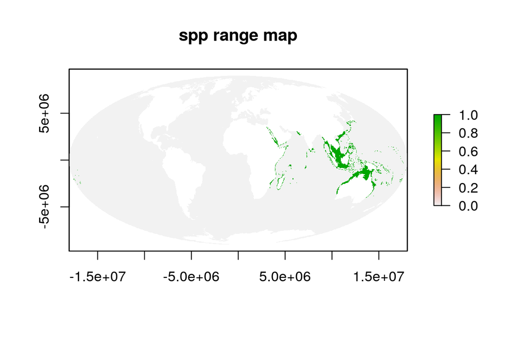

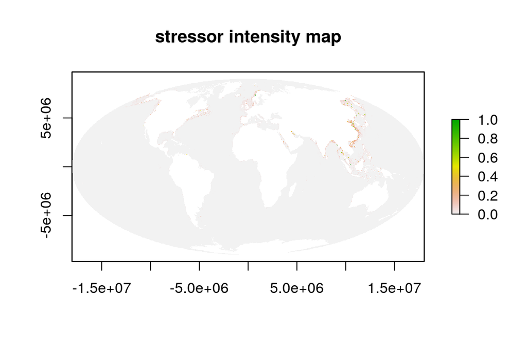

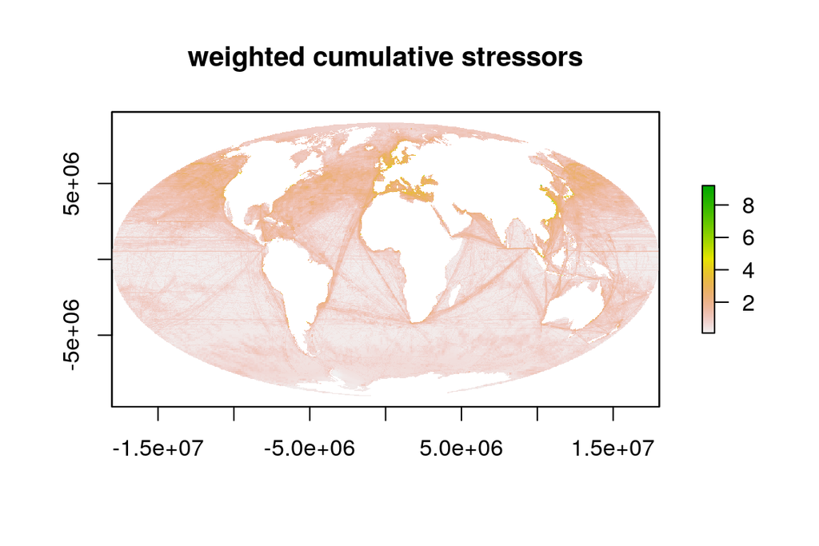

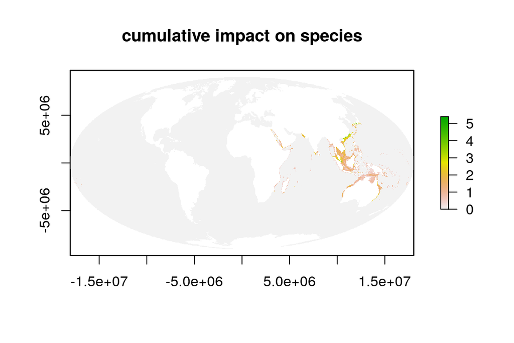

```
## [1] NA
```